# Deliverable_2

Varsha Krish

1/27/2022

## Cluster Analysis

```r
rds_link <- 'https://github.com/varshaskrish/comp-thinking/raw/main/Project/alldata_long_OK_SNAP_DOH.RDS'
rds_data <- url(rds_link)

#read in data
py_data <- readRDS(file = rds_data)
```

## Prepare data

The datais structured correctly from Python but some of the variable names still need a little editing so they will display nicely in figures and are all the same unit.

```r
## create a copy of the dataset
dataTest_full <- as.data.table(copy(py_data))

## clean the dataset for clustering use
setnames(dataTest_full, old = c("Population (2020)",
                           "WA_adults_cost_prohibited_healthcare_access_pct_2019_bycounty",
                           "WA_adults_flu_shot_pct_2019_bycounty",
                           "WA_adult_poor_mental_health_pct_2019_bycounty",
                           "WA_adult_binge_drinking_pct_2019_bycounty",
                           "WA_maternal_smoking_pct_2019_bycounty",
                           "WA_women_early_prenatal_care_access_pct_2019_bycounty",
                           "WA_adults_with_personal_health_care_provider_pct_2019_bycounty"),

         new = c("pop_2020",
                 "cost_of_care", "flu_shot", "mental_health", "binge_drinking", "maternal_smoke", "prenatal_care", "PCP_access"))

### only use the 2019 data
dataTest_full <- dataTest_full[year == 2019]

### transform the SNAP number households and percent uninsured to per-capita rates
dataTest_full[, snap_pc := (snap/pop_2020)*100]

## transfor the primary care access to no primary care access
dataTest_full[, noPCP_access := 100-PCP_access]

# create a new dataframe for later use
dataMap <- copy(dataTest_full)
```

Test the distribution of the data by county, year for NEGATIVE indicators of health equity (.i.e. measures that have a negative effect on health)

```r
### remove uneeded cols
dataTest <- copy(dataTest_full)

dataTest <- dataTest[, c('year', 'pop_2020', 'snap'):=NULL]

# REMOVE HOUSEHOLD INCOME AND FLU SHOT
dataTest <- dataTest[, c('he','flu_shot', 'prenatal_care', 'PCP_access', 'noPCP_access'):=NULL]

## set the county names as row names and remove the numeric household income est
dataTest <- as.data.frame(dataTest) #only dataframes get rownames

row.names(dataTest)=dataTest$County
dataTest$County=NULL
```

Test the distribtuion of the two per-capita variables

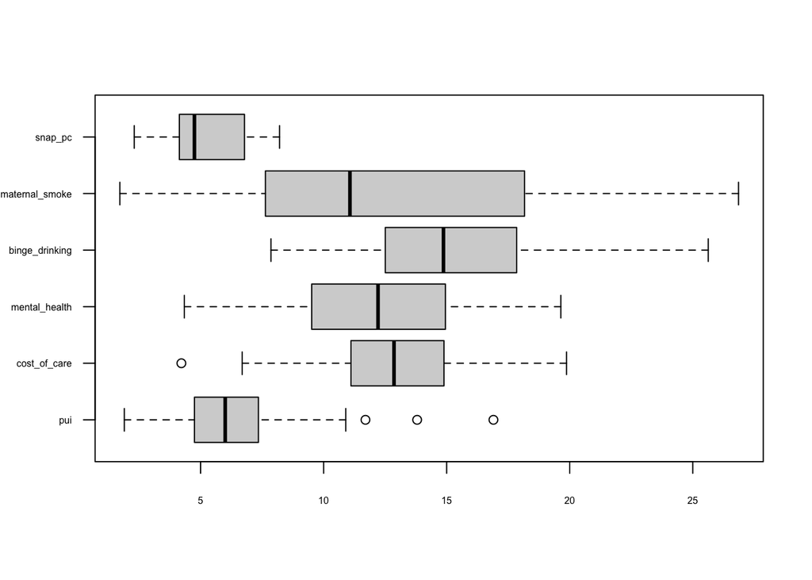

```r
boxplot(dataTest, horizontal = T, cex.axis = 0.5, las=1)
```

This looks good -- all the chosen measures have approdimately similar distributions.

## Computing the Distance Matrix

```r
dataToCluster <- copy(dataTest)

## set a random seed
set.seed(999)

## pick a distance method and compute distance matrix
dataToCluster_DM=daisy(x=dataToCluster, metric = "gower")
```

## Test clustering models

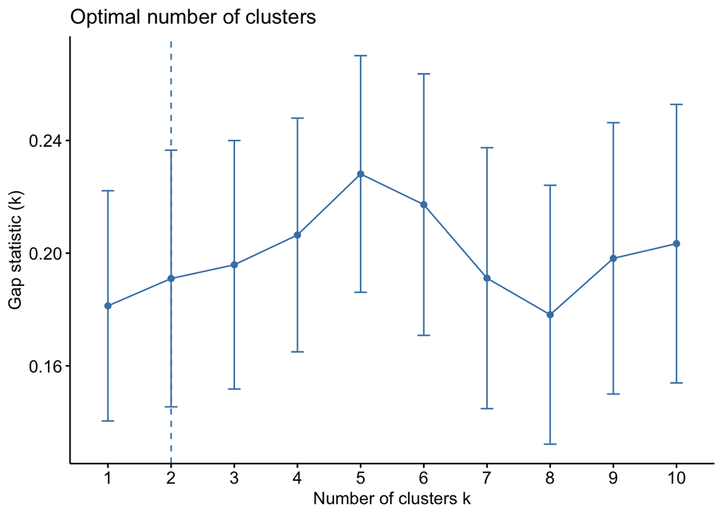

```r
fviz_nbclust(dataToCluster,
             pam,
             diss=dataToCluster_DM,
             method = "gap_stat",
             k.max = 10,
             verbose = F)
```

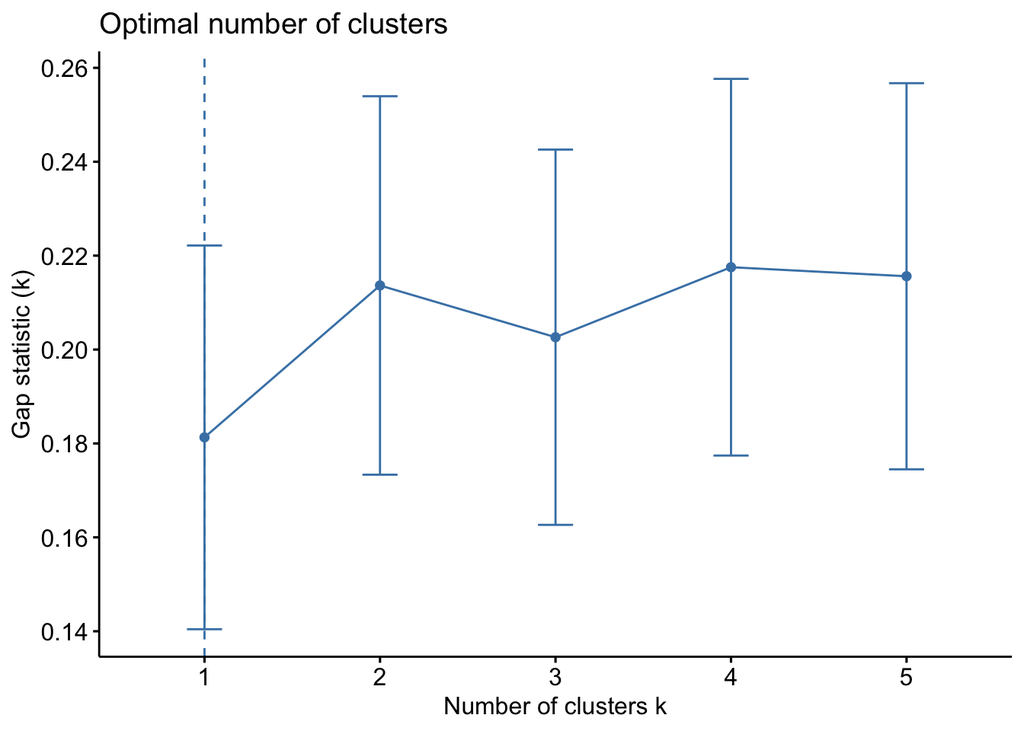

```r
fviz_nbclust(dataToCluster,
             hcut,
             diss=dataToCluster_DM,
             method = "gap_stat",
             k.max = 5,
             verbose = F,
             hc_func = "agnes")
```

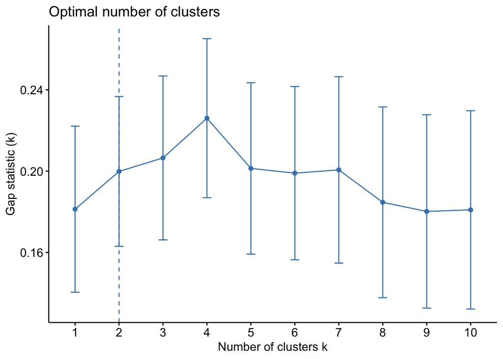

```r
fviz_nbclust(dataToCluster,
             hcut,
             diss=dataToCluster_DM,
             method = "gap_stat",
             k.max = 10,
             verbose = F,
             hc_func = "diana")
```

Both the Pam and Diana clustering functions suggested using 2 clusters...  
This makes sense with what we know about health outcomes in WA state (Eastern WA and Western WA have distinct health profiles)

Now apply the clustering function...

```r
NumberOfClusterDesired=2

# Partitioning technique
res.pam = pam(x=dataToCluster_DM,
              k = NumberOfClusterDesired,
              cluster.only = F)

# Hierarchical technique- agglomerative approach
res.agnes = hcut(dataToCluster_DM,
                k = NumberOfClusterDesired,
                isdiss=TRUE,
                hc_func='agnes',
                hc_method = "ward.D2")

# Hierarchical technique- divisive approach
res.diana = hcut(dataToCluster_DM,
                k = NumberOfClusterDesired,
                isdiss=TRUE,
                hc_func='diana',
                hc_method = "ward.D2")
```

### Add results back to the original full dataframe

```r
dataMap$pam=as.factor(res.pam$clustering)
dataMap$agn=as.factor(res.agnes$cluster)
dataMap$dia=as.factor(res.diana$cluster)


## verify the ordinatliy -- not really necessary with 2 clusters??
aggregate(data=dataMap, pui~pam, FUN=mean)
```

```
##   pam      pui
## 1   1 7.064000
## 2   2 5.664286
```

```r
aggregate(data=dataMap, pui~agn, FUN=mean)
```

```
##   agn      pui
## 1   1 6.985000
## 2   2 6.115789
```

```r
aggregate(data=dataMap, pui~dia, FUN=mean)
```

```
##   dia      pui
## 1   1 5.468750
## 2   2 7.321739
```

## Evaluate results.

### Plot silhouettes

```
##   cluster size ave.sil.width
## 1       1   25          0.32
## 2       2   14          0.27
```

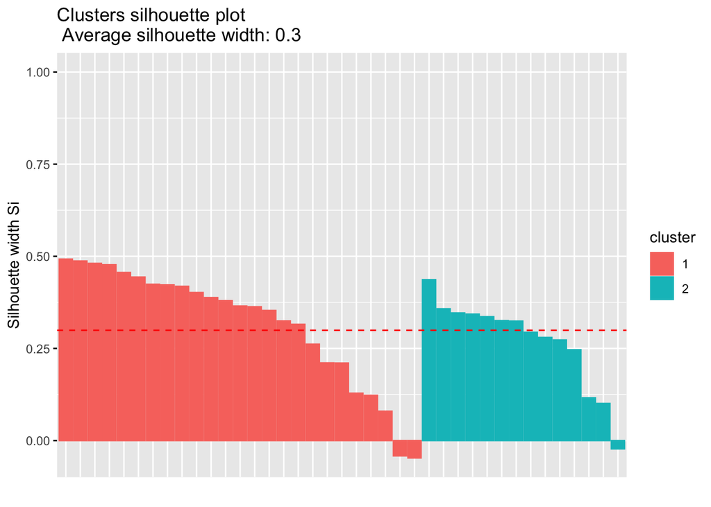

```r
fviz_silhouette(res.pam)
```

```
##   cluster size ave.sil.width
## 1       1   20          0.10
## 2       2   19          0.44
```

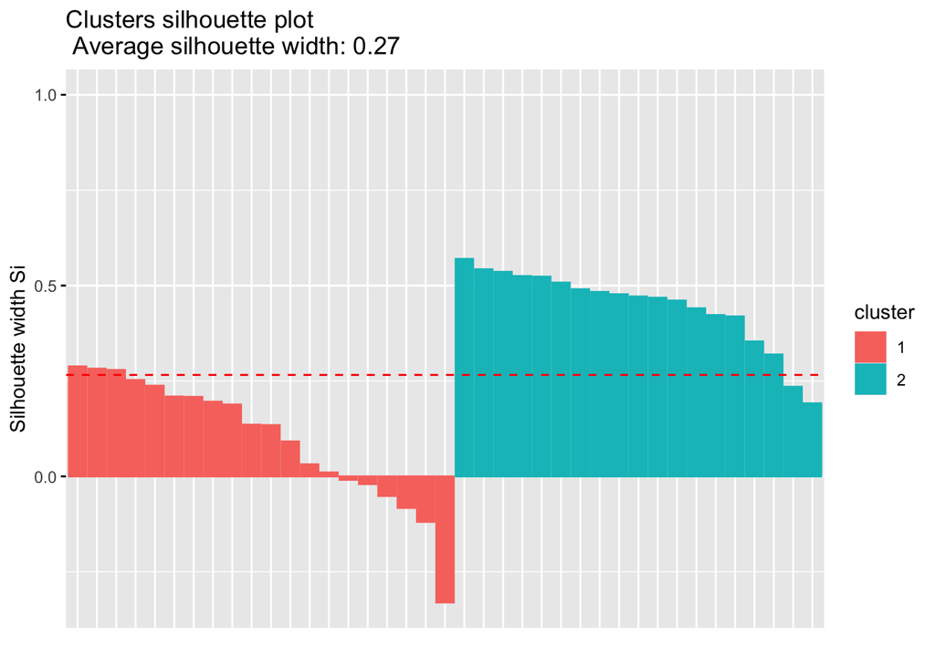

```r
fviz_silhouette(res.agnes)
```

```
##   cluster size ave.sil.width
## 1       1   16          0.21
## 2       2   23          0.37
```

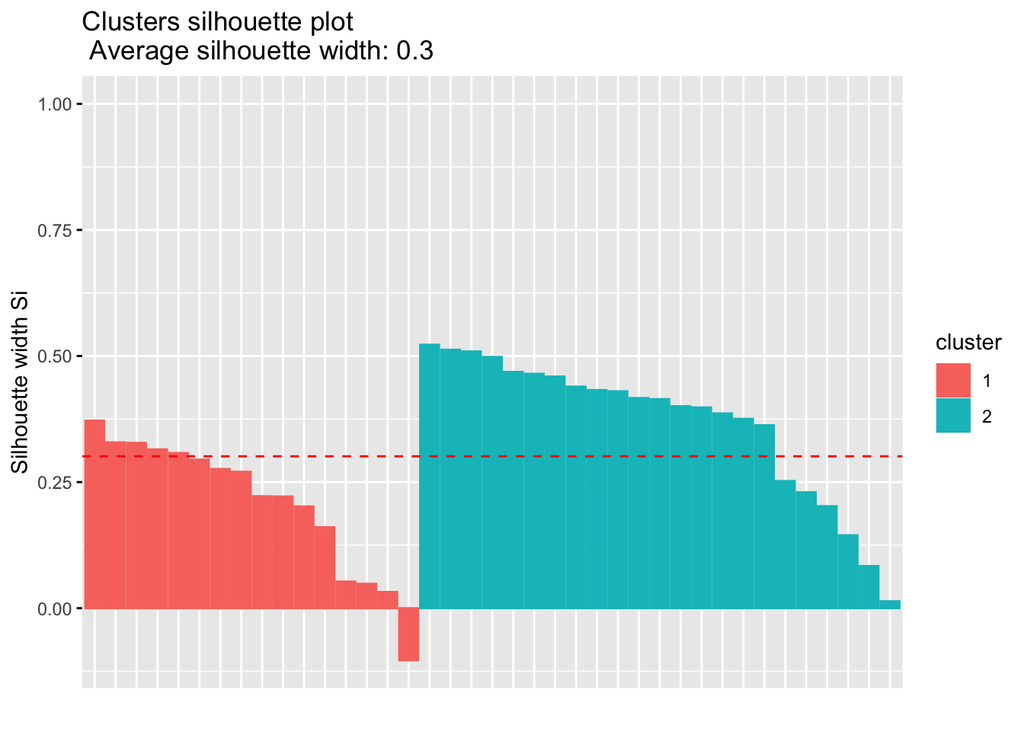

```r
fviz_silhouette(res.diana)
```

Of the three clustering stratigies, the Diana function best captured the data with only 1 negative sihouette. The Agnes function was the worset model at capturing theses data in clusters.

## Compare the clustering

First keep all the negative sihouette counties

```r
#pull clustering data into a dataframe
pamEval=data.frame(res.pam$silinfo$widths)
agnEval=data.frame(res.agnes$silinfo$widths)
diaEval=data.frame(res.diana$silinfo$widths)

#filter out only the negative sil locs
pamPoor=rownames(pamEval[pamEval$sil_width<0,])
agnPoor=rownames(agnEval[agnEval$sil_width<0,])
diaPoor=rownames(diaEval[diaEval$sil_width<0,])
```

```r
neg_Clus <- as.data.frame(qpcR:::cbind.na(sort(pamPoor), sort(agnPoor),sort(diaPoor)))
names(neg_Clus) = c("pam","agn","dia")

#see all the poorly clustered locs
neg_Clus
```

```
##        pam         agn   dia
## 1  Lincoln       Adams Adams
## 2 Okanogan    Franklin  <NA>
## 3   Yakima       Grant  <NA>
## 4     <NA>   Klickitat  <NA>
## 5     <NA>     Lincoln  <NA>
## 6     <NA> Walla Walla  <NA>
```

As noted above, Diana had only 1 negative silhouette whereas Agness had 6.

Now map the distances to compare the three different clustering models

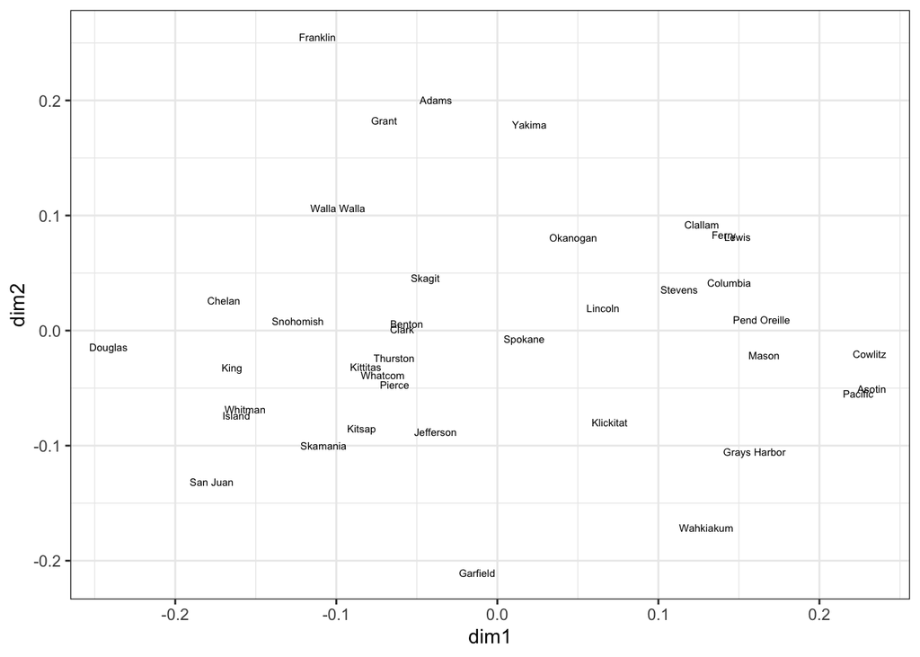

```r
#use the distance matrix data from earlier
projectedData <- cmdscale(dataToCluster_DM, k=2)

dataMap$dim1 <- projectedData[,1]
dataMap$dim2 <- projectedData[,2]

# map
baseMap <- ggplot(data=dataMap,
               aes(x=dim1, y=dim2, label=County)) +
  geom_text(size=2) +
  theme_bw()

baseMap
```

Now color the counties by their cluster for each of the 3 models and add location name annotations

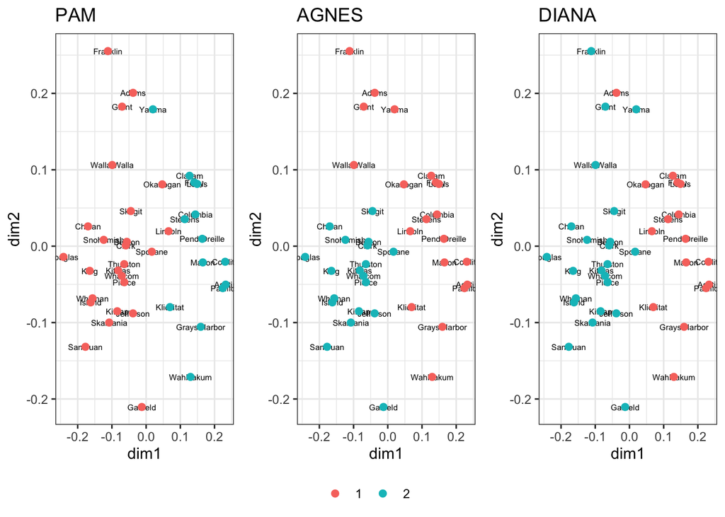

```r
pamMap = baseMap +
  labs(title = "PAM") +
  geom_point(size=2, aes(color=pam)) +
  theme(legend.position = 'bottom', legend.title = element_blank())

map_leg <- g_legend(pamMap)
pamMap <- pamMap + theme(legend.position = 'none')

agnMap = baseMap +
  labs(title = "AGNES") +
  geom_point(size=2, aes(color=agn), show.legend = F)

diaMap = baseMap +
  labs(title = "DIANA") +
  geom_point(size=2, aes(color=dia), show.legend = F)


grid.arrange(arrangeGrob(pamMap, agnMap, diaMap, nrow= 1), map_leg, nrow=2, heights = c(10,1))
```

Annotate only the outlier counties

```r
LABELpam=ifelse(dataMap$County %in% pamPoor, dataMap$County, "")
LABELagn=ifelse(dataMap$County %in% agnPoor, dataMap$County, "")
LABELdia=ifelse(dataMap$County %in% diaPoor, dataMap$County, "")
```

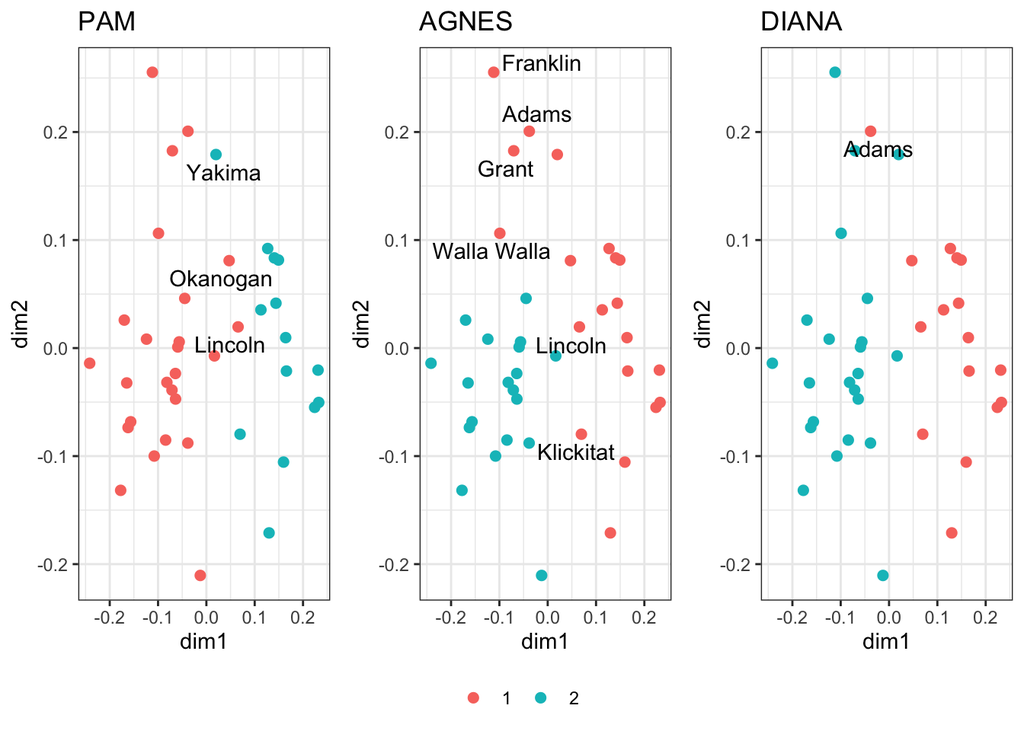

```r
#remove the text labels for all counties and add in only the poor mapped loc naems
pamMap$layers <- pamMap$layers[2]
pamMap<- pamMap + geom_text_repel(aes(label=LABELpam))

agnMap$layers <- agnMap$layers[2]
agnMap<- agnMap + geom_text_repel(aes(label=LABELagn))

diaMap$layers <- diaMap$layers[2]
diaMap<- diaMap + geom_text_repel(aes(label=LABELdia))

grid.arrange(arrangeGrob(pamMap, agnMap, diaMap, nrow= 1), map_leg, nrow=2, heights = c(10,1))
```

Also can look at this clustering through a Dendogram visual approach:

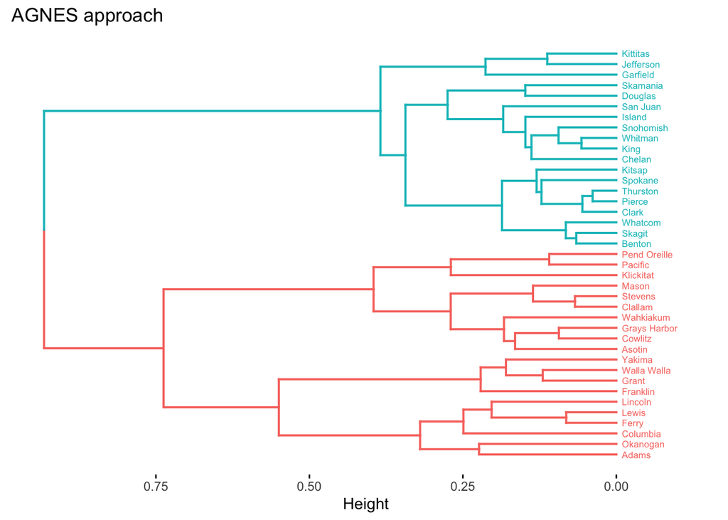

```r
fviz_dend(res.agnes,k=NumberOfClusterDesired, cex = 0.45, horiz = T,main = "AGNES approach")
```

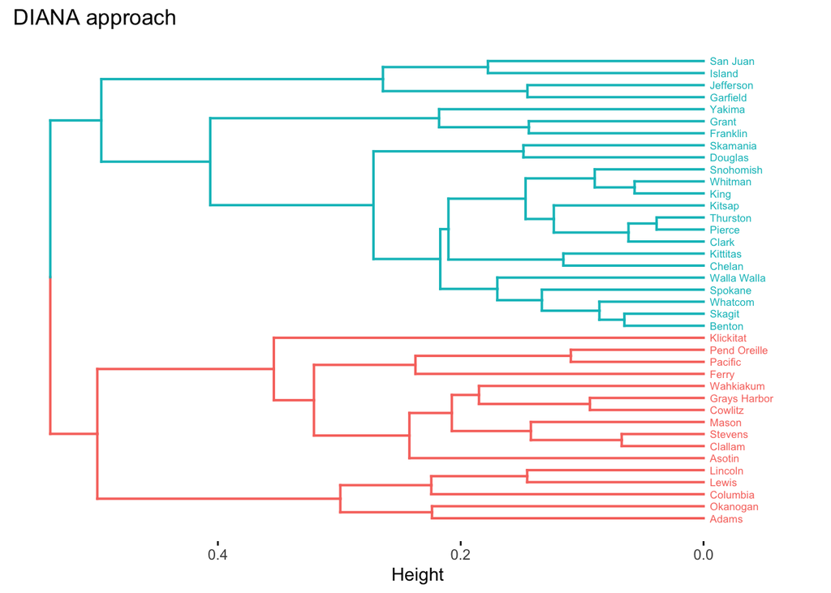

```r
fviz_dend(res.diana,k=NumberOfClusterDesired, cex = 0.45, horiz = T,main = "DIANA approach")
```

## Factor Analysis

```r
dataforFA <- copy(dataTest)
setDT(dataforFA, keep.rownames = 'County')
```

```r
model='healthequ=~cost_of_care + mental_health + binge_drinking + maternal_smoke + snap_pc' ## snap_pc removed for sake of variance from other indicators

fit <- cfa(model, data = dataforFA, std.lv=TRUE)
indexCFA = lavPredict(fit)
#indexCFANorm[1:10]

# rescale the values from 0 to 100 to match the Percent Uninsured Access
indexCFANorm <- rescale(as.vector(indexCFA), to = c(0, 100))
indexCFANorm[1:10]
```

```
##  [1] 73.16582 67.09966 36.35743 18.92356 51.59113 28.59667 70.73457 90.07818
##  [9] 33.38650 67.11905
```

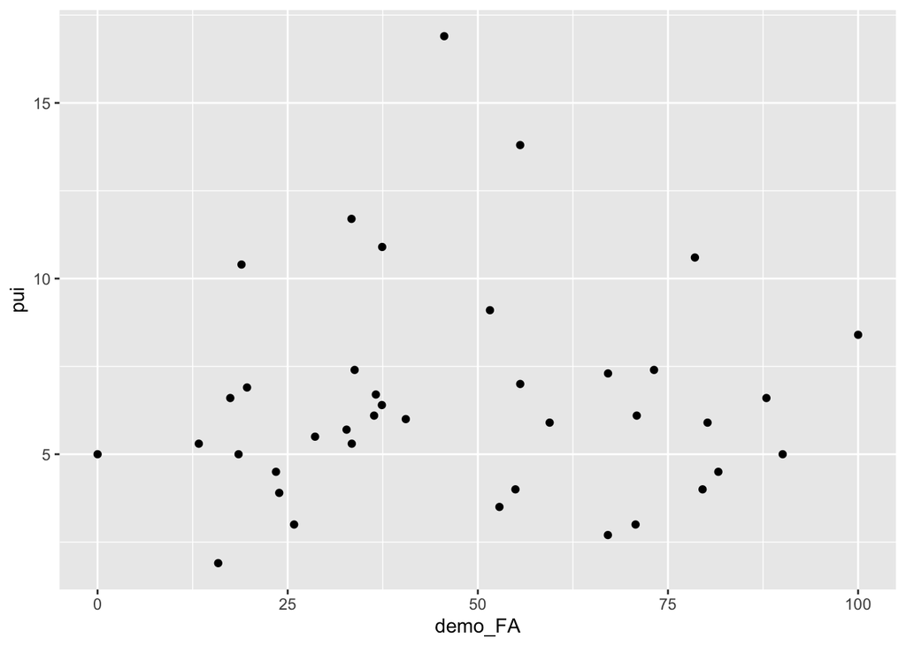

```r
dataMap$demo_FA <- indexCFANorm

base_FA <- ggplot(data=dataMap, aes(x=demo_FA, y=pui)) +
  geom_point()

base_FA
```

When lookign at the outcomes of this factor analysis, it looks like there are not enough data to conclusively suggest that lack of health insurance (pui) can reliably predict a set of negative health outcomes (demo_FA).

## Regression Analysis

### Explainatory Approach

First: Test two hypotheses 1. Hypothesis 1: no primary care access positvely coorelates with (increases) percent uninsured (only) 2. Hypothesis 2: no primary care access positvely coorelates with (increases) percent uninsured and negative indicators of health equality (aka. five indicators better predict lack of access to primary care provider)

Run regrssion models for both hypotheses

```r
# hypothesis 1
hypo1 <- formula(pui~ noPCP_access)

gauss1=glm(hypo1,
           data = dataMap,
           family = 'gaussian')

# hypothesis 2
hypo2 <- formula(pui~ noPCP_access + cost_of_care + mental_health + binge_drinking + maternal_smoke)

gauss2=glm(hypo2,
           data = dataMap,
           family = 'gaussian')
```

Test Hypothesis 1

```r
summary(gauss1)
```

```
##
## Call:
## glm(formula = hypo1, family = "gaussian", data = dataMap)
##
## Deviance Residuals:
##     Min       1Q   Median       3Q      Max
## -5.1691  -1.8813  -0.6377   0.7463  10.3319
##
## Coefficients:
##              Estimate Std. Error t value Pr(>|t|)
## (Intercept)   5.69821    1.61027   3.539   0.0011 **
## noPCP_access  0.03205    0.05685   0.564   0.5763
## ---
## Signif. codes:  0 '***' 0.001 '**' 0.01 '*' 0.05 '.' 0.1 ' ' 1
##
## (Dispersion parameter for gaussian family taken to be 9.693796)
##
##     Null deviance: 361.75  on 38  degrees of freedom
## Residual deviance: 358.67  on 37  degrees of freedom
## AIC: 203.21
##
## Number of Fisher Scoring iterations: 2
```

Test Hypothesis 2

```r
summary(gauss2)
```

```
##
## Call:
## glm(formula = hypo2, family = "gaussian", data = dataMap)
##
## Deviance Residuals:
##    Min      1Q  Median      3Q     Max
## -3.617  -1.746  -0.721   1.887   6.475
##
## Coefficients:
##                Estimate Std. Error t value Pr(>|t|)
## (Intercept)     9.57234    2.70309   3.541 0.001211 **
## noPCP_access    0.03509    0.04860   0.722 0.475308
## cost_of_care    0.14625    0.14990   0.976 0.336350
## mental_health   0.05681    0.11554   0.492 0.626170
## binge_drinking -0.18759    0.10145  -1.849 0.073417 .
## maternal_smoke -0.28989    0.07148  -4.056 0.000287 ***
## ---
## Signif. codes:  0 '***' 0.001 '**' 0.01 '*' 0.05 '.' 0.1 ' ' 1
##
## (Dispersion parameter for gaussian family taken to be 6.82066)
##
##     Null deviance: 361.75  on 38  degrees of freedom
## Residual deviance: 225.08  on 33  degrees of freedom
## AIC: 193.04
##
## Number of Fisher Scoring iterations: 2
```

Which of the 2 models is a better predictor for lack of access to PCP?

```r
anova(gauss1,gauss2,test="Chisq")
```

```
## Analysis of Deviance Table
##
## Model 1: pui ~ noPCP_access
## Model 2: pui ~ noPCP_access + cost_of_care + mental_health + binge_drinking +
##     maternal_smoke
##   Resid. Df Resid. Dev Df Deviance  Pr(>Chi)
## 1        37     358.67
## 2        33     225.08  4   133.59 0.0006027 ***
## ---
## Signif. codes:  0 '***' 0.001 '**' 0.01 '*' 0.05 '.' 0.1 ' ' 1
```

The **second test** is perhaps a better predictor...  
Find the RSquared

```r
rsq(gauss1,adj=T)
```

```
## [1] -0.01827755
```

and plot the model to see colinearity

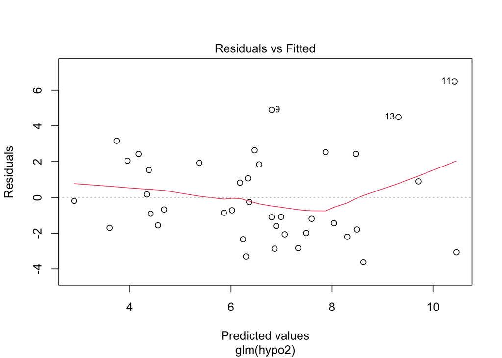

```r
plot(gauss2,1)
```

This model does not hold a clear linear relationship as higher percents of negative health outcomes (higher Predicted values). However, at lower percents it is relatively close. However, more data is needed to conclusively state a clear relationship.

Are the residuals normal?

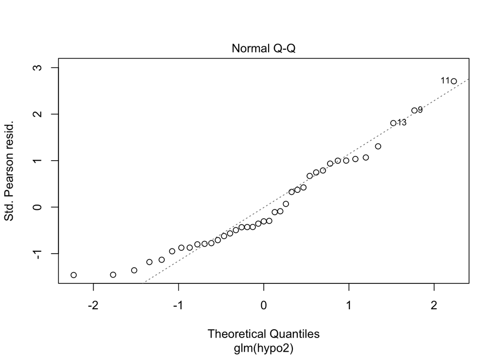

```r
#visual representation
plot(gauss2,2)
```

```r
#mathmatical representation
shapiro.test(gauss2$residuals)
```

```
##
##  Shapiro-Wilk normality test
##
## data:  gauss2$residuals
## W = 0.9452, p-value = 0.05669
```

The residuals are fairly normally distriburted. (p value > 0.05)

Now test for homoscedasticity (similar distribution of resudials along the predictors)

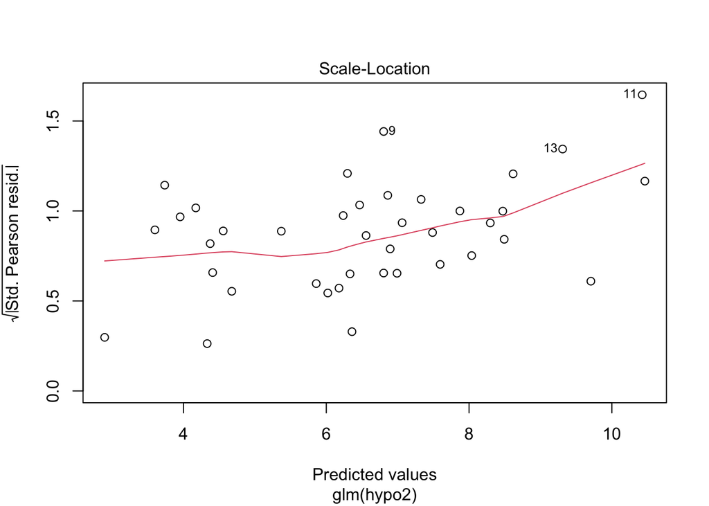

```r
#visual exploration
plot(gauss2, 3)
```

```r
#mathmatical representation
bptest(gauss2)
```

```
##
##  studentized Breusch-Pagan test
##
## data:  gauss2
## BP = 8.9742, df = 5, p-value = 0.1101
```

We can assume Homoscedasticity because the pvalue is >0.05.

Let's assume that there is no colinearity here between the 5 indicators for negative health effects

```r
vif(gauss2)
```

```
##   noPCP_access   cost_of_care  mental_health binge_drinking maternal_smoke
##       1.038626       1.190581       1.095647       1.044064       1.125800
```

Since all values are < 5 we can confirm that there is no apparent colineratiy between these health effects with this data.

#### Outliers and Atypical Effects

First look to see what points may be outliers

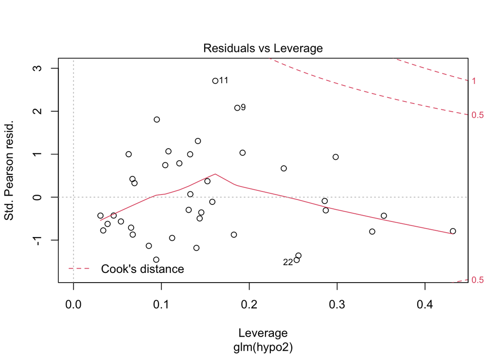

```r
plot(gauss2,5)
```

```r
gaussInf=as.data.frame(influence.measures(gauss2)$is.inf)
gaussInf[gaussInf$cook.d,]
```

```
##  [1] dfb.1_   dfb.nPCP dfb.cs__ dfb.mnt_ dfb.bng_ dfb.mtr_ dffit    cov.r
##  [9] cook.d   hat
## <0 rows> (or 0-length row.names)
```

No data point seems to be a statistical outlier...  
No point is beyond Cook's distance

### Now just visually plot the regression -- see the estimate of each variable

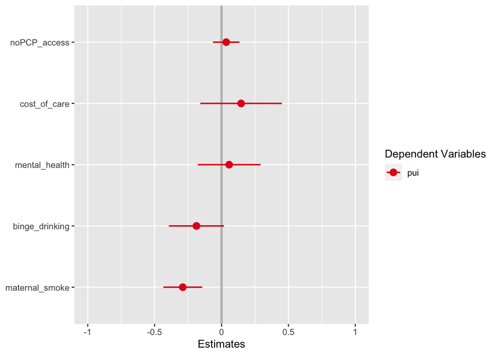

```r
plot_models(gauss2, vline.color = "grey")
```

Percent of mothers who have smoked during any tiem pregnant is the only sig. indicator for likelyhood of being uninsured. (p <.001)

## Predictive Approach

```r
set.seed(123)

selection = createDataPartition(dataMap$pui,
                                p = 0.75,
                                list = FALSE)
# traning dataset
trainGauss = dataMap[ selection, ]

# testing (validation) dataset
testGauss  = dataMap[-selection, ]
```

Regress with the training dataset using cross validation to test 5 samples

```r
ctrl = trainControl(method = 'cv',number = 5) #5 samples

gauss2CV = train(hypo2,
                 data = trainGauss,
                 method = 'glm',
                 trControl = ctrl)

gauss2CV
```

```
## Generalized Linear Model
##
## 31 samples
##  5 predictor
##
## No pre-processing
## Resampling: Cross-Validated (5 fold)
## Summary of sample sizes: 25, 25, 26, 23, 25
## Resampling results:
##
##   RMSE      Rsquared  MAE
##   2.998176  0.494004  2.648347
```

And now evaluate these sampled set back against the original data (testing dataset)

```r
predictedVal<-predict(gauss2CV,testGauss)

postResample(obs = testGauss$pui,
             pred=predictedVal)
```

```
##       RMSE   Rsquared        MAE
## 2.12333390 0.09031175 1.73525311
```

### Expalinatory Approach

Re-make the first 2 hypothesis and run log regression for both... First need to make a binary variable out of percent uninsured (pui) -- predictive variable

```r
# create binary varaible
dataMap[, pui_binary := ifelse(pui > median(pui,na.rm = T), 1, 0)]

# factor the predictive variable
dataMap$pui=factor(dataMap$pui_binary)

# hypothesis 1
hypoDico1 <- formula(pui_binary~ noPCP_access)

Logi1=glm(hypoDico1,
           data = dataMap,
           family = 'binomial')

# hypothesis 2
hypoDico2 <- formula(pui_binary~ noPCP_access + cost_of_care + mental_health + binge_drinking + maternal_smoke)

Logi2=glm(hypoDico2,
           data = dataMap,
           family = 'binomial')
```

See hypotheses tests

```r
summary(Logi1)
```

```
##
## Call:
## glm(formula = hypoDico1, family = "binomial", data = dataMap)
##
## Deviance Residuals:
##    Min      1Q  Median      3Q     Max
## -1.222  -1.156  -1.104   1.199   1.237
##
## Coefficients:
##               Estimate Std. Error z value Pr(>|z|)
## (Intercept)  -0.219914   1.036323  -0.212    0.832
## noPCP_access  0.006259   0.036576   0.171    0.864
##
## (Dispersion parameter for binomial family taken to be 1)
##
##     Null deviance: 54.040  on 38  degrees of freedom
## Residual deviance: 54.011  on 37  degrees of freedom
## AIC: 58.011
##
## Number of Fisher Scoring iterations: 3
```

```r
summary(Logi2)
```

```
##
## Call:
## glm(formula = hypoDico2, family = "binomial", data = dataMap)
##
## Deviance Residuals:
##     Min       1Q   Median       3Q      Max
## -1.7889  -0.9509  -0.3530   0.9094   1.8986
##
## Coefficients:
##                Estimate Std. Error z value Pr(>|z|)
## (Intercept)     3.33266    2.71350   1.228   0.2194
## noPCP_access    0.01819    0.04832   0.376   0.7067
## cost_of_care    0.19499    0.14082   1.385   0.1661
## mental_health  -0.08026    0.11205  -0.716   0.4738
## binge_drinking -0.21697    0.10485  -2.069   0.0385 *
## maternal_smoke -0.16368    0.07806  -2.097   0.0360 *
## ---
## Signif. codes:  0 '***' 0.001 '**' 0.01 '*' 0.05 '.' 0.1 ' ' 1
##
## (Dispersion parameter for binomial family taken to be 1)
##
##     Null deviance: 54.040  on 38  degrees of freedom
## Residual deviance: 42.603  on 33  degrees of freedom
## AIC: 54.603
##
## Number of Fisher Scoring iterations: 4
```

Comapre models

```r
lrtest(Logi1,Logi2)
```

```
## Likelihood ratio test
##
## Model 1: pui_binary ~ noPCP_access
## Model 2: pui_binary ~ noPCP_access + cost_of_care + mental_health + binge_drinking +
##     maternal_smoke
##   #Df  LogLik Df  Chisq Pr(>Chisq)
## 1   2 -27.005
## 2   6 -21.301  4 11.408    0.02234 *
## ---
## Signif. codes:  0 '***' 0.001 '**' 0.01 '*' 0.05 '.' 0.1 ' ' 1
```

The second test is better at predicing beign uninsured (p<0.05)

### Verify the situation of the model...

Linearity Assumption

```r
DataRegLogis=dataMap
DataRegLogis$PCP_accessTEST=dataMap$noPCP_access*log(dataMap$noPCP_access)
DataRegLogis$carecostTEST=dataMap$cost_of_care*log(dataMap$cost_of_care)
DataRegLogis$mentalhealthTEST=dataMap$mental_health*log(dataMap$mental_health)
DataRegLogis$bingedrinkTEST=dataMap$binge_drinking*log(dataMap$binge_drinking)
DataRegLogis$matersmokeTEST=dataMap$maternal_smoke*log(dataMap$maternal_smoke)

DicoTest=formula(pui_binary~ noPCP_access + cost_of_care + mental_health + binge_drinking + maternal_smoke +
                   PCP_accessTEST + carecostTEST + mentalhealthTEST + bingedrinkTEST + matersmokeTEST)

summary(glm(DicoTest,data=DataRegLogis,family = binomial))
```

```
##
## Call:
## glm(formula = DicoTest, family = binomial, data = DataRegLogis)
##
## Deviance Residuals:
##      Min        1Q    Median        3Q       Max
## -1.82546  -0.73691  -0.08856   0.80278   2.16326
##
## Coefficients:
##                   Estimate Std. Error z value Pr(>|z|)
## (Intercept)      -24.15697   17.06023  -1.416    0.157
## noPCP_access       1.00943    1.19025   0.848    0.396
## cost_of_care       3.71068    3.17752   1.168    0.243
## mental_health      2.79987    2.88804   0.969    0.332
## binge_drinking    -0.11697    2.39368  -0.049    0.961
## maternal_smoke    -0.20827    1.07286  -0.194    0.846
## PCP_accessTEST    -0.22788    0.28196  -0.808    0.419
## carecostTEST      -1.02099    0.89611  -1.139    0.255
## mentalhealthTEST  -0.84951    0.82485  -1.030    0.303
## bingedrinkTEST    -0.03118    0.64108  -0.049    0.961
## matersmokeTEST     0.04648    0.31202   0.149    0.882
##
## (Dispersion parameter for binomial family taken to be 1)
##
##     Null deviance: 54.040  on 38  degrees of freedom
## Residual deviance: 38.312  on 28  degrees of freedom
## AIC: 60.312
##
## Number of Fisher Scoring iterations: 5
```

```r
vif(Logi2)
```

```
##   noPCP_access   cost_of_care  mental_health binge_drinking maternal_smoke
##       1.039334       1.367672       1.126358       1.155339       1.392990
```

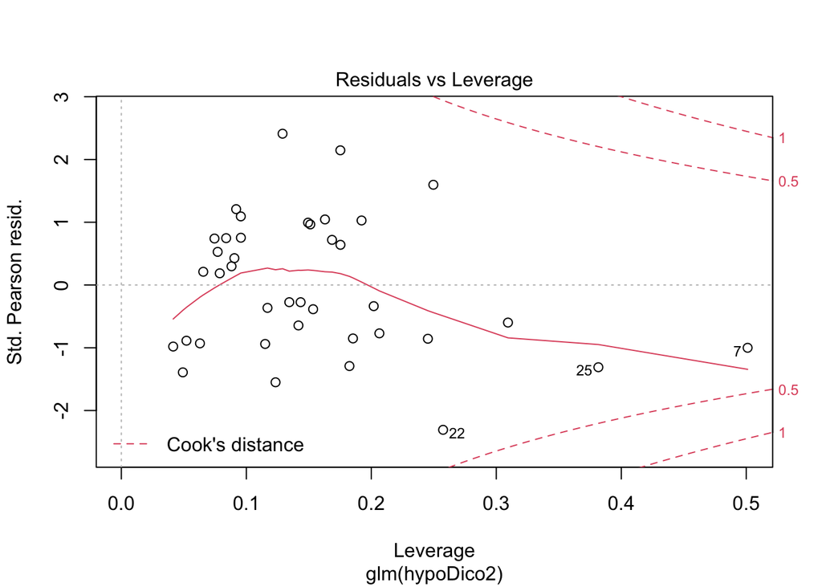

```r
#visual expression
plot(Logi2,5)
```

Now visualize the marginal effects of each indicator on health equity

```r
(modelChosen = margins(Logi2))
```

```
## Average marginal effects
```

```
## glm(formula = hypoDico2, family = "binomial", data = dataMap)
```

```
##  noPCP_access cost_of_care mental_health binge_drinking maternal_smoke
##      0.003374      0.03618      -0.01489       -0.04026       -0.03037
```

```r
(margins=summary(modelChosen))
```

```
##          factor     AME     SE       z      p   lower   upper
##  binge_drinking -0.0403 0.0153 -2.6304 0.0085 -0.0703 -0.0103
##    cost_of_care  0.0362 0.0238  1.5198 0.1286 -0.0105  0.0828
##  maternal_smoke -0.0304 0.0114 -2.6668 0.0077 -0.0527 -0.0081
##   mental_health -0.0149 0.0204 -0.7300 0.4654 -0.0549  0.0251
##    noPCP_access  0.0034 0.0089  0.3786 0.7050 -0.0141  0.0208
```

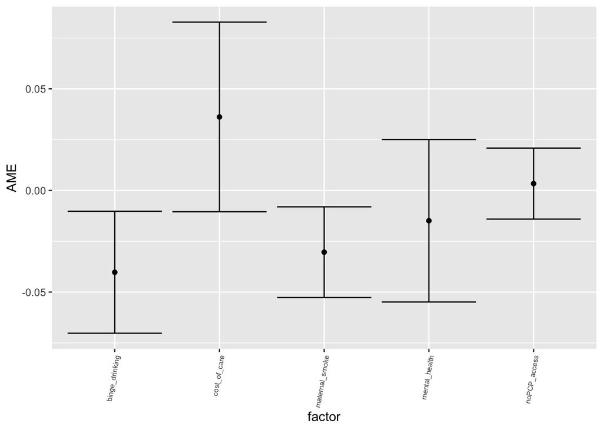

```r
base <- ggplot(margins,
               aes(x=factor, y=AME)) +
  geom_point() +
  geom_errorbar(aes(ymin=lower, ymax=upper))

plot_ME <- base + theme(axis.text.x = element_text(angle = 80, size = 6, hjust = 1))

plot_ME
```

### Predictive Approach

Step 1: Split the data -- prep for regression

```r
selection <- createDataPartition(dataMap$pui_binary, p = 0.75, list = FALSE)
dataMap$pui_binary <- as.factor(dataMap$pui_binary)

# create a training dataset and a testing dataset
trainLogi = dataMap[selection, ]
testLogi  = dataMap[-selection, ]
```

Step 2: Regress using 5 samples from the training data

```r
set.seed(123) #random seed

ctrl = trainControl(method = 'cv', number = 5)

Logis2CV = train(hypoDico2,
                 data = trainLogi,
                 method = 'glm',
                 family="binomial",
                 trControl = ctrl)
```

```r
Logis2CV
```

```
## Generalized Linear Model
##
## 30 samples
##  5 predictor
##  2 classes: '0', '1'
##
## No pre-processing
## Resampling: Cross-Validated (5 fold)
## Summary of sample sizes: 24, 24, 24, 24, 24
## Resampling results:
##
##   Accuracy   Kappa
##   0.5666667  0.1333333
```

Step 3: See results & evaluate performance

```r
predictions = predict(Logis2CV,
                      newdata=testLogi,
                      type='raw')

# assess
confusionMatrix(data=predictions,
                reference=factor(testLogi$pui_binary),
                positive = "1")
```

```
## Confusion Matrix and Statistics
##
##           Reference
## Prediction 0 1
##          0 3 1
##          1 2 3
##
##                Accuracy : 0.6667
##                  95% CI : (0.2993, 0.9251)
##     No Information Rate : 0.5556
##     P-Value [Acc > NIR] : 0.3743
##
##                   Kappa : 0.3415
##
##  Mcnemar's Test P-Value : 1.0000
##
##             Sensitivity : 0.7500
##             Specificity : 0.6000
##          Pos Pred Value : 0.6000
##          Neg Pred Value : 0.7500
##              Prevalence : 0.4444
##          Detection Rate : 0.3333
##    Detection Prevalence : 0.5556
##       Balanced Accuracy : 0.6750
##
##        'Positive' Class : 1
##
```

Unfortunately, with a p-value > 0.05 this model is not accurate.